# Spark Beyond Package Examples

[figure not shown]

# A. Basic modeling

## Basic classification

[figure not shown]

#### Overview

Goal: Predict Titanic Passenger Survival  
This example demonstrates how to perform a simple classification. We will use data from the famous Kaggle competition to predict whether a passenger will survive.

#### Training data

We can retrieve the titanic train data by calling `data = getData("titanic_train")`. The column `survived` represents whether a Titanic passenger survived.  
To make the problem slightly more difficult we will remove the `sex` and `age` columns using the `excludeCols` function.

```r
data = getData("titanic_train")
data = excludeCols(data, c("sex", "age"))
```

[1] "sex, age were removed" [1] "Note: the input object is of type data.frame hence, a new data.frame with the excluded columns will be returned."

```r
#View(data) # in order to view the data in an RStudio tab
print(xtable(data[1:5,]), type='html', comment=F)
```

|  | survived | pclass | name | sibsp | parch | ticket | fare | cabin | embarked |
| --- | --- | --- | --- | --- | --- | --- | --- | --- | --- |
| 1 | 0 | 3 | Braund, Mr. Owen Harris | 1 | 0 | A/5 21171 | 7.25 |  | S |
| 2 | 1 | 1 | Cumings, Mrs. John Bradley (Florence Briggs Thayer) | 1 | 0 | PC 17599 | 71.28 | C85 | C |
| 3 | 1 | 3 | Heikkinen, Miss. Laina | 0 | 0 | STON/O2. 3101282 | 7.92 |  | S |
| 4 | 1 | 1 | Futrelle, Mrs. Jacques Heath (Lily May Peel) | 1 | 0 | 113803 | 53.10 | C123 | S |
| 5 | 0 | 3 | Allen, Mr. William Henry | 0 | 0 | 373450 | 8.05 |  | S |

#### Pipeline

Feature search and model building are performed via the `learn` function.

Before we can start learning we will need to log in.

```r
login(username = "user@example.com", password = "12345", domain="http://")
```

```r
titanicSurvivedModel = learn(
    projectName = "titanic_survived",
    trainData = data,
    target = "survived"
)
```

#### Top features

On the Titanic most children and women were rescued first, hence had higher survival rates. The first feature that was generated, identifies the column `name` as PersonName and effectively captures the gender information conveyed in this column.

Here are the top 3 features (each contains a lift signal pointing to which class each feature suggests). We can get them by calling the `features()` method of the Session object which will return them as a data frame.

```r
print(xtable(titanicSurvivedModel$features()[1:3,c("feature", "Lift.0", "Lift.1")]), type='html', comment=F)
```

|  | feature | Lift.0 | Lift.1 |
| --- | --- | --- | --- |
| 1 | name.inferredGender != Some(male) | 0.49 | 1.84 |
| 2 | pclass != 3 | 0.72 | 1.45 |
| 3 | numberIn(ticket) in range (8854.5, 231932) | 0.61 | 1.64 |

To view an html reports with all the information on the features and the model.

```r
#webView
titanicSurvivedModel$webView()

#show train features
titanicSurvivedModel$showFeaturesTrain()

#show test features
titanicSurvivedModel$showFeaturesTest()

#show how the test features are compared to the train features
titanicSurvivedModel$showFeatureStability()
```

#### Evaluation

The `evaluate` method returns the model evaluation statistics

```r
evaluation = titanicSurvivedModel$evaluate()
```

```r
## === Detailed Accuracy By Class ===
##
## Class           TP Rate   FP Rate   Precision   Recall   F-Measure   ROC Area   Gini
##
## 0               0.888     0.324     0.798       0.888    0.841       0.865      0.73
## 1               0.676     0.112     0.806       0.676    0.735       0.865      0.73
## Weighted Avg.   0.801     0.238     0.802       0.801    0.798       0.865      0.73
##
```

## Basic regression

[figure not shown]

#### Overview

Goal: Predict Titanic Passenger  
This example demonstrates how to perform a simple regression using the SparkBeyond platform. We will use the same titanic data but now we will aim to predict the column `age`.

#### Training data

Here are all the columns available:

```r
data = getData("titanic_train")
#View(data) # in order to view the data in an RStudio tab
print(xtable(data[1:5,]), type='html', comment=F)
```

|  | survived | pclass | name | sex | age | sibsp | parch | ticket | fare | cabin | embarked |
| --- | --- | --- | --- | --- | --- | --- | --- | --- | --- | --- | --- |
| 1 | 0 | 3 | Braund, Mr. Owen Harris | male | 22.00 | 1 | 0 | A/5 21171 | 7.25 |  | S |
| 2 | 1 | 1 | Cumings, Mrs. John Bradley (Florence Briggs Thayer) | female | 38.00 | 1 | 0 | PC 17599 | 71.28 | C85 | C |
| 3 | 1 | 3 | Heikkinen, Miss. Laina | female | 26.00 | 0 | 0 | STON/O2. 3101282 | 7.92 |  | S |
| 4 | 1 | 1 | Futrelle, Mrs. Jacques Heath (Lily May Peel) | female | 35.00 | 1 | 0 | 113803 | 53.10 | C123 | S |
| 5 | 0 | 3 | Allen, Mr. William Henry | male | 35.00 | 0 | 0 | 373450 | 8.05 |  | S |

#### Pipeline

The problem was automatically identified as a regression problem because the target is continuous.

```r
titanicAgeModel = learn(
    projectName = "titanic_age",
    trainData = data,
    target = "age"
)
```

#### Top features

```r
print(xtable(titanicAgeModel$features()[1:20,c("feature", "RIG")]), type='html', comment=F)
```

|  | feature | RIG |
| --- | --- | --- |
| 1 | name contains master | 0.04 |
| 2 | pclass < 3 | 0.04 |
| 3 | wordFrequencies(name).valueOf(miss) orIfMissing 0.5773502691896258 < 0.5386751345948129 | 0.02 |
| 4 | parch in range (0, 3.5) | 0.04 |
| 5 | fare < 9.54375 | 0.03 |
| 6 | embarked == Q | 0.02 |
| 7 | normalizedNgrams(name) does not contain (mr) | 0.04 |
| 8 | sibsp in range (3.5, 6.5) | 0.03 |
| 9 | numberOfWords(name) < 4 | 0.02 |
| 10 | sentimentDistribution(name) == Map((0, 3)) | 0.02 |
| 11 | cabin.size in range (2.5, 4.5) | 0.03 |
| 12 | name.inferredGender == None | 0.02 |
| 13 | sentimentDistribution(name) contains (0, 3) | 0.01 |
| 14 | upperCaseRatio(ticket) == 0.1111 | 0.01 |
| 15 | ceil(fare) == 12.0 | 0.01 |
| 16 | upperCaseRatio(name) >= 0.16172624237140365 | 0.01 |
| 17 | parch != 0 | 0.04 |
| 18 | smallSubsets(cabin) contains List(1) | 0.01 |
| 19 | name contains "" | 0.01 |
| 20 | cos(fare) in range (-0.05638243077105439, 0.1326807604187568) | 0.01 |

#### Evaluation

```r
evaluation =  titanicAgeModel$evaluate()
```

```r
##
## Correlation coefficient             0.64839
## R2                                  0.42041
## Mean absolute error                 7.91608
## Root mean squared error             10.934383
## Relative absolute error             75.4454456 %
## Root relative squared error         76.63504678 %
## Root relative prior squared error   14.2681227
## Actuals mean                        30.22055249
## Estimations mean                    29.78955612
## Actuals std                         14.26712733
## Estimations std                     8.06795146
## Total Number of Instances           181
##
```

# B. Basic controls

## Feature Generation Control

### Function exclusions

[figure not shown]

#### Overview

Goal: Predict Titanic Passenger Age  
This example demonstrates two important capabilities:  
1. controlling the number of features in the output  
2. excluding elements from the generated features.  
For example in order to reduce overfit, we would like generate only 25 features. (Or alternatively, create either 25 features or 50 features and use the model the performs better on cross validation of the training set.) This can be set in the `maxFeaturesCount` of `featureGeneration`.  
In addition, we would prefer to not create mathematical features (such as "ceil"), trigonometry features, and also exclude features that contains the word "master". These can be set via the `functionsBlackList` parameter to exclude these terms.  
Please refer to the SparkBeyond function catalog by calling `functionCatalog()` to view the list of functions and associated domains Lastly, you can notice that in this example we are using the `featureSearch` capability instead of the regular `learn` without actually building a model.

#### Pipeline

```r
data = getData("titanic_train")
titanicAgeFeatures = featureSearch(
    projectName = "titanic_age_exclusions",
    trainData = data,
    target = "age",

    featureGeneration = featureGenerationControl(
        #limit the number of features to 25
        maxFeaturesCount = 25, #list(25,50)
        # blacklist trigonometric functions, "abs" function, and features containing "master"
        functionsBlackList = list("trigonometry", "ceil", "master")
    )
)
```

#### Top features

Note that compared to the regular regression example, the `master` feature does not exist (as well as 'ceil' and trignometry).

```r
print(xtable(titanicAgeFeatures$features()[1:20,c("idx", "feature")]), type='html', comment=F)
```

|  | idx | feature |
| --- | --- | --- |
| 1 | 0 | parch in range (0, 3.5) |
| 2 | 1 | pclass < 3 |
| 3 | 2 | normalizedNgrams(name) does not contain (mr) |
| 4 | 3 | fare < 9.54375 |
| 5 | 4 | embarked == Q |
| 6 | 5 | extractKeys(sentimentDistribution(name)) contains 1.0 |
| 7 | 6 | sibsp in range (3.5, 6.5) |
| 8 | 7 | name.inferredGender == None |
| 9 | 8 | name contains miss |
| 10 | 9 | numberOfWords(name) < 4 |
| 11 | 10 | sentimentDistribution(name) == Map((0, 3)) |
| 12 | 11 | cabin.size in range (2.5, 4.5) |
| 13 | 12 | sentimentDistribution(name) contains (0, 3) |
| 14 | 13 | upperCaseRatio(ticket) == 0.1111 |
| 15 | 14 | upperCaseRatio(name) >= 0.16172624237140365 |
| 16 | 15 | parch != 0 |
| 17 | 16 | floor(fare) == 11.0 |
| 18 | 17 | smallSubsets(cabin) contains List(1) |
| 19 | 18 | name contains "" |
| 20 | 19 | wordFrequencies(name).valueOf(alexander) orIfMissing 0.5773502691896258 < 0.5386751345948129 |

### Preprocessing control - Pizza

### Training data

```r
data = read.csv("http://s3.amazonaws.com/public-sparkbeyond/pizza_full.csv", stringsAsFactors = FALSE)
data = excludeCols(data, c("giver_username_if_known",
                                                     "requester_days_since_first_post_on_raop_at_request",
                                                     "requester_days_since_first_post_on_raop_at_retrieval",
                                                     "requester_number_of_posts_on_raop_at_request",
                                                     "requester_number_of_posts_on_raop_at_retrieval",
                                                     "requester_number_of_comments_in_raop_at_request",
                                                     "requester_number_of_comments_in_raop_at_retrieval",
                                                     "requester_user_flair"))
```

```r
## [1] "giver_username_if_known, requester_days_since_first_post_on_raop_at_request, requester_days_since_first_post_on_raop_at_retrieval, requester_number_of_posts_on_raop_at_request, requester_number_of_posts_on_raop_at_retrieval, requester_number_of_comments_in_raop_at_request, requester_number_of_comments_in_raop_at_retrieval, requester_user_flair were removed"
## [1] "Note: the input object is of type data.frame hence, a new data.frame with the excluded columns will be returned."
```

```r
print(data[1,"request_text"])
```

```r
## [1] "I'm not in College, or a starving artist or anything like that. I've just been a bit unlucky lately. I'm a 36 year old single guy with a job. But rent, and other bills killed me this month. I thought I had enough funds in my account to at least keep me set with Mr. Noodles, I forgot about my monthly banking fee.  I had a small bag of chips Wednesday afternoon, and I get paid Monday, so I'll be fine then.. It's just really painful at this point and food is something I'm constantly thinking about.  I've got a few bucks to get on the bus to work on Saturday, so I can't really use that.  I'm really embarrassed to even be asking like this and I'm not sure how it works, so please be patient with me.  I guess that covers it. Thank you in advance.  Cheers folks."
```

#### Pipeline

```r
pizzaModel = learn(
    projectName = "pizza",
    trainData = data,
    target = "requester_received_pizza",
    preProcessing = preProcessingControl(fileEscaping = FALSE)
)
```

#### Topfeatures

```r
print(xtable(pizzaModel$features()[1:3,c("RIG", "feature", "Lift.false", "Lift.true")]), type='html', comment=F)
```

|  | RIG | feature | Lift.false | Lift.true |
| --- | --- | --- | --- | --- |
| 1 | 0.12 | request_number_of_comments_at_retrieval >= 2 | 0.78 | 1.72 |
| 2 | 0.04 | requester_upvotes_minus_downvotes_at_retrieval < 12 | 1.20 | 0.35 |
| 3 | 0.01 | evenness(request_number_of_comments_at_retrieval) == 1 | 0.91 | 1.30 |

#### Evaluation

```r
e=pizzaModel$evaluate()$summary
```

```r
## === Detailed Accuracy By Class ===
##
## Class           TP Rate   FP Rate   Precision   Recall   F-Measure   ROC Area   Gini
##
## true            0.207     0.034     0.633       0.207    0.313       0.766      0.533
## false           0.966     0.793     0.81        0.966    0.881       0.766      0.533
## Weighted Avg.   0.797     0.624     0.77        0.797    0.754       0.766      0.533
##
```

### Cuisine Classification

Goal: Predict Cuisine type from an Ingredient list

#### Training data

```r
library(jsonlite)
download.file("http://s3.amazonaws.com/public-sparkbeyond/yummly.json.gz","./yummly.json.gz")
yummlyData = sampleData(fromJSON(readLines("./yummly.json.gz")), 0.3)
print(yummlyData[1, c("cuisine","ingredients")])
```

```r
##       cuisine
## 10561 italian
##                                                                                               ingredients
## 10561 unsalted butter, water, sharp cheddar cheese, kosher salt, whole milk, ground black pepper, polenta
```

```r
yummlyModel=learn(
    projectName="Yummly",
    trainData = yummlyData,
    target = "cuisine",
    featureGeneration = featureGenerationControl(maxFeaturesCount = list(50))
)
```

#### Top features

```r
print(xtable(yummlyModel$features()[1:5,c("RIG", "feature")]), type='html', comment=F)
```

|  | RIG | feature |
| --- | --- | --- |
| 1 | 0.07 | normalizedNgrams(seqToTextList(ingredients)) contains (soi, sauc) |
| 2 | 0.05 | seqToTextList(ingredients) contains cilantro |
| 3 | 0.05 | normalizedNgrams(seqToTextList(ingredients)) contains (oliv) |
| 4 | 0.06 | stemmedWordsWithoutCommonTerms(seqToTextList(ingredients)) contains ginger |
| 5 | 0.04 | stemmedWordsWithoutCommonTerms(seqToTextList(ingredients)) contains tortilla |

#### Evaluation

```r
evaluation = yummlyModel$evaluate()
```

```r
## === Detailed Accuracy By Class ===
##
## Class           TP Rate   FP Rate   Precision   Recall   F-Measure   ROC Area   Gini
##
## thai            0.634     0.011     0.694       0.634    0.663       0.961      0.921
## greek           0.569     0.005     0.759       0.569    0.651       0.926      0.852
## french          0.363     0.035     0.455       0.363    0.404       0.884      0.767
## korean          0.568     0.003     0.75        0.568    0.646       0.968      0.937
## spanish         0.03      0.002     0.286       0.03     0.055       0.818      0.636
## cajun_creole    0.5       0.013     0.587       0.5      0.54        0.92       0.841
## moroccan        0.596     0.007     0.66        0.596    0.626       0.879      0.758
## filipino        0.392     0.007     0.541       0.392    0.455       0.901      0.801
## southern_us     0.664     0.116     0.438       0.664    0.528       0.879      0.757
## russian         0         0.002     0           0        0           0.833      0.665
## brazilian       0.258     0.003     0.533       0.258    0.348       0.911      0.823
## indian          0.823     0.01      0.873       0.823    0.847       0.971      0.941
## british         0.047     0.001     0.4         0.047    0.083       0.789      0.578
## jamaican        0.321     0.0       0.9         0.321    0.474       0.884      0.768
## irish           0         0.0       0           0        0           0.762      0.524
## italian         0.816     0.123     0.613       0.816    0.7         0.924      0.849
## vietnamese      0.397     0.004     0.697       0.397    0.505       0.955      0.911
## japanese        0.361     0.01      0.603       0.361    0.452       0.871      0.742
## mexican         0.864     0.042     0.791       0.864    0.826       0.956      0.912
## chinese         0.742     0.028     0.633       0.742    0.683       0.957      0.914
## Weighted Avg.   0.628     0.051     0.613       0.628    0.603       0.916      0.832
##
```

###Countries Distance Goal: Predict (calculate) the distance between two given countries

#### Training data

```r
countriesDistance = getData("countries_distance")
print(xtable(head(countriesDistance,n=5)), type='html', comment=F)
```

|  | country1 | country2 | distance |
| --- | --- | --- | --- |
| 1 | french southern and antarctic lands | federated states of micronesia | 6202.32 |
| 2 | ecuador | gibraltar | 5312.52 |
| 3 | bosnia and herzegovina | ethiopia | 2782.68 |
| 4 | ascension | jersey | 4507.93 |
| 5 | india | ethiopia | 2734.49 |

#### Pipeline

```r
countryModel=learn(projectName="CountriesDistance",countriesDistance,"distance",
    featureGeneration = featureGenerationControl(maxFeaturesCount = list(50))
)
```

#### Top features

```r
print(xtable(countryModel$features()[1:5,c("RIG", "feature")]), type='html', comment=F)
```

|  | RIG | feature |
| --- | --- | --- |
| 1 | 0.38 | normalizeByDeciles(country1.distanceFrom(country2)) < 0.49869474945012415 |
| 2 | 0.03 | stemmedWordsWithoutCommonTerms(country2) contains island |
| 3 | 0.02 | compressionDistance(country1, country2) >= 0.9023809523809524 |
| 4 | 0.03 | sentimentDistribution(country2) does not contain (0, 1) |
| 5 | 0.01 | compressionDistance(country1, country2) == 0.9167 |

#### Evaluation

```r
evaluation = countryModel$evaluate()
```

```r
##
## Correlation coefficient             0.99412
## R2                                  0.988274
## Mean absolute error                 149.251767
## Root mean squared error             315.121625
## Relative absolute error             6.28897266 %
## Root relative squared error         11.12831087 %
## Root relative prior squared error   2831.71119445
## Actuals mean                        5313.96994394
## Estimations mean                    5321.18604002
## Actuals std                         2831.7090959
## Estimations std                     2742.79547289
## Total Number of Instances           611
##
```

### Spam Email

Goal: Predict whether or not an email contains spam based on given statistics (UCI)

#### Training data

```r
spam = getData("spambase")
print(xtable(head(spam[,1:7],n=5)), type='html', comment=F)
```

|  | word_freq_make | word_freq_address | word_freq_all | word_freq_3d | word_freq_our | word_freq_over | word_freq_remove |
| --- | --- | --- | --- | --- | --- | --- | --- |
| 1 | 0.21 | 0.28 | 0.50 | 0.00 | 0.14 | 0.28 | 0.21 |
| 2 | 0.06 | 0.00 | 0.71 | 0.00 | 1.23 | 0.19 | 0.19 |
| 3 | 0.00 | 0.00 | 0.00 | 0.00 | 0.63 | 0.00 | 0.31 |
| 4 | 0.00 | 0.00 | 0.00 | 0.00 | 0.63 | 0.00 | 0.31 |
| 5 | 0.00 | 0.00 | 0.00 | 0.00 | 1.85 | 0.00 | 0.00 |

#### Pipeline

```r
spamModel=learn(projectName="spambase",spam,"isSpam",
    featureGeneration = featureGenerationControl(maxFeaturesCount = list(50))
)
```

#### Top features

```r
print(xtable(spamModel$features()[1:5,c("RIG", "feature","Lift.0","Lift.1")]), type='html', comment=F)
```

|  | RIG | feature | Lift.0 | Lift.1 |
| --- | --- | --- | --- | --- |
| 1 | 0.25 | char_freq_4 >= 0.0555 | 0.20 | 2.23 |
| 2 | 0.25 | char_freq_3 >= 0.0795 | 0.46 | 1.83 |
| 3 | 0.23 | word_freq_remove != 0.0 | 0.08 | 2.41 |
| 4 | 0.16 | word_freq_hp >= 0.12 | 1.60 | 0.09 |
| 5 | 0.19 | word_freq_free >= 0.095 | 0.31 | 2.06 |

#### Evaluation

```r
evaluation = spamModel$evaluate()
```

```r
## === Detailed Accuracy By Class ===
##
## Class           TP Rate   FP Rate   Precision   Recall   F-Measure   ROC Area   Gini
##
## 0               0.961     0.071     0.955       0.961    0.958       0.983      0.966
## 1               0.929     0.039     0.939       0.929    0.934       0.983      0.966
## Weighted Avg.   0.948     0.059     0.948       0.948    0.948       0.983      0.966
##
```

# C. Text analysis

## Text analysis - tweets sentiment

[figure not shown]

### Internal text functions

#### Overview

Goal: Identify sentiment in twitter tweets. The sentiment dataset contains a column with a tweet and a setiment target (-1 or 1).

#### Training data

```r
tweets = getData("tweets_sentiment")
print(xtable(head(tweets,n=5)), type='html', comment=F)
```

|  | sentiment | tweet |
| --- | --- | --- |
| 1 | 1 | Performance proves is far from finished |
| 2 | 1 | Defensive show against Sunderland best of the season |
| 3 | 1 | A day to remember pleased with victory |
| 4 | 1 | Loan move was the making of me |
| 5 | 1 | Best form this season has coincided with him starting in the centre of midfield |

#### Pipeline

```r
SentimentModel = learn(
    projectName="tweets",
    trainData=tweets,
    target="sentiment",
    featureGeneration = featureGenerationControl(maxFeaturesCount = list(40))
)
```

#### Top features

The top feature is a textSentimentScore which is automatically computed.

```r
print(xtable(SentimentModel$features()[1:5,c("feature", "RIG")]), type='html', comment=F)
```

|  | feature | RIG |
| --- | --- | --- |
| 1 | textSentimentScore(tweet) < -0.017857142857142856 | 0.27 |
| 2 | extractKeys(sentimentDistribution(tweet)) == List(1, 0) | 0.19 |
| 3 | tweet contains great | 0.12 |
| 4 | wordFrequencies(tweet).valueOf(best) orIfMissing 0 >= 0.17349064404453718 | 0.08 |
| 5 | numberIn(tweet) == -1.0 | 0.09 |

#### Evaluation

```r
SentimentModelEval = SentimentModel$evaluate()
```

```r
## === Detailed Accuracy By Class ===
##
## Class           TP Rate   FP Rate   Precision   Recall   F-Measure   ROC Area   Gini
##
## -1              1         0.28      0.781       1        0.877       0.869      0.738
## 1               0.72      0         1           0.72     0.837       0.869      0.738
## Weighted Avg.   0.86      0.14      0.891       0.86     0.857       0.869      0.738
##
```

### Terms Map context

[figure not shown]

#### Overview

In order to improve performance we can include a custom context Dataset. The sentimentLexicon includes over 6000 single words with a either a positive or negative sentiment. The top features now are actually derived by looking up the values in the lexcion (data_column) and the classificaiton performance is boosted.

#### Context data

```r
lexicon = getData("sentiment_lexicon")
print(xtable(head(lexicon, n=5)), type='html', comment=F)
```

|  | Words | Sentiment |
| --- | --- | --- |
| 1 | abound | 1 |
| 2 | abounds | 1 |
| 3 | abundance | 1 |
| 4 | abundant | 1 |
| 5 | accessable | 1 |

#### Pipeline

Based on the column types in the context data, various context objects can be created. See contextTypesList for complete information on all possible context object types. It is also possible to define the requested context types to be generated explicitly in contextObject. Specifically, in this case we will define a Terms Map context.

```r
SentimentModelContext = learn(
    projectName = "tweets",
    trainData = tweets,
    target = "sentiment",
    contextDatasets = list(contextObject(data = getData("sentiment_lexicon"), name = "sentiment_lexicon",
        contextTypes = contextTypesList(termsMap = TRUE))), #defining the context type explicity
    featureGeneration = featureGenerationControl(maxFeaturesCount = list(40))
)
```

#### Top features

```r
print(xtable(SentimentModelContext$features()[1:5,c("feature", "RIG")]), type='html', comment=F)
```

|  | feature | RIG |
| --- | --- | --- |
| 1 | extractKeys(entitiesHistogram(tweet, sentiment_lexicon_lexicon)) == List(1) | 0.42 |
| 2 | extractKeys(entitiesHistogram(tweet, sentiment_lexicon_lexicon)) == List(-1) | 0.34 |
| 3 | textSentimentScore(tweet) < -0.017857142857142856 | 0.27 |
| 4 | tweet contains great | 0.12 |
| 5 | extractKeys(entitiesHistogram(tweet, sentiment_lexicon_lexicon)) does not contain -1 | 0.35 |

#### Evaluation

```r
SentimentContextEval = SentimentModelContext$evaluate()
```

```r
## === Detailed Accuracy By Class ===
##
## Class           TP Rate   FP Rate   Precision   Recall   F-Measure   ROC Area   Gini
##
## -1              0.96      0.12      0.889       0.96     0.923       0.982      0.965
## 1               0.88      0.04      0.957       0.88     0.917       0.982      0.965
## Weighted Avg.   0.92      0.08      0.923       0.92     0.92        0.982      0.965
##
```

### Inverted Index context

#### Overview

In this example we will see how to add an Inverted Index context. Specifically, this will allow us to use similar textual instances to augment the feature search, in a KNN-fashion. In this example, during the training, only the context information of the train data will be made available for feature search purposes. However, during prediction, the context information of both the train data and the test data can be made available.

#### Pipeline

We will first split the data into train and test data using the trainTestSplit function.

```r
trainTestData=trainTestSplit(tweets,0.5)
SentimentModelContext2 = learn(
    projectName="tweets_semtiment3",
    trainData=trainTestData$train,
    testData =trainTestData$test,
    target="sentiment",
    featureGeneration = featureGenerationControl(maxFeaturesCount = list(40)),
    contextDatasets = list(contextObject(data = trainTestData$train, name = "tweets_context",
                contextTypes = contextTypesList(invertedIndex = TRUE))), #defining the context type explicitly
    autoSave = FALSE
)
```

#### Top features

```r
print(xtable(SentimentModelContext2$features()[1:5,c("feature", "RIG")]), type='html', comment=F)
```

|  | feature | RIG |
| --- | --- | --- |
| 1 | textSentimentScore(tweet) < -0.017857142857142856 | 0.28 |
| 2 | weightedAverageOf3MostSimilar(tweets_context_text_index_of_tweet_with_attributes, tweet).valueOf(sentiment) orIfMissing -1 >= 0.40339977700357676 | 0.12 |
| 3 | wordFrequencies(tweet).valueOf(the) orIfMissing 0 >= 0.33569751761237 | 0.09 |
| 4 | extractKeys(sentimentDistribution(tweet)) == List(1, 0) | 0.18 |
| 5 | wordFrequencies(tweet).valueOf(best) orIfMissing 0 >= 0.17349064404453718 | 0.10 |

#### Evaluation

```r
   length(which(pred$sentiment==pred$sentiment_predicted))/nrow(pred) * 100
```

```r
## [1] 95.86207
```

# D. GeoSpatial analysis

## Geo spatial context

#### Overview

Using Geospatial KNN in order to infer from near by locations that have similar properties.  
In this example we pass the input also as a context data. A GeoSpatial Index object will be created, keeping properties for each coordinate that were provided. A set of KNN based functions can be triggered for the geoSpatial index object, that can collect and aggregate properties from near by locations. Note that the actual location is not used to prevent target leaks.

#### Training data

The input dataset contains locations in the world (based on a lat/long) and the language spoken at this location (for top 15 most spoken languages).

```r
langData =  getData("languages")
print(xtable(langData[1:5,]), type='html', comment=F)
```

|  | lang | long | lat |
| --- | --- | --- | --- |
| 1 | en | -77.07 | 41.81 |
| 2 | en | -106.13 | 28.66 |
| 3 | tr | 29.37 | 40.81 |
| 4 | es | -6.14 | 36.70 |
| 5 | und | -0.10 | 51.50 |

#### Pipeline

```r
languagesModel = learn(
    projectName = "languages",
    trainData = langData,
    target = "lang",
    contextDatasets = list(contextObject(data=langData, name="languages",
        contextTypes = contextTypesList(geoSpatial = TRUE))),
    featureGeneration = featureGenerationControl(maxFeaturesCount = list(25))
)
```

#### Top features

```r
print(xtable(languagesModel$features()[1:10,c("idx","feature","Lift.en","Lift.es")]), type='html', comment=F)
```

|  | idx | feature | Lift.en | Lift.es |
| --- | --- | --- | --- | --- |
| 1 | 0 | latLong.longitude >= 19.795355999999998 | 0.55 | 0.02 |
| 2 | 1 | latLong.latitude < 21.1515635 | 0.53 | 1.79 |
| 3 | 2 | mostFrequentFromClosest3WeightedByDistance(latLong, languages_lang_by_location) == en | 2.15 | 0.23 |
| 4 | 3 | mostFrequentFromClosest3WeightedByDistance(latLong, languages_lang_by_location) == es | 0.23 | 5.48 |
| 5 | 4 | mostFrequentFromClosest3WeightedByDistance(latLong, languages_lang_by_location) == pt | 0.25 | 0.33 |
| 6 | 5 | mostFrequentFromClosest3WeightedByDistance(latLong, languages_lang_by_location) == tr | 0.19 | 0.02 |
| 7 | 6 | mostFrequentFromClosest3WeightedByDistance(latLong, languages_lang_by_location) == ru | 0.15 | 0.03 |
| 8 | 7 | mostFrequentFromClosest3WeightedByDistance(latLong, languages_lang_by_location) == ja | 0.20 | 0.00 |
| 9 | 8 | mostFrequentFromClosest3WeightedByDistance(latLong, languages_lang_by_location) == in | 0.68 | 0.13 |
| 10 | 9 | mostFrequentFromClosest3WeightedByDistance(latLong, languages_lang_by_location) == ar | 0.49 | 0.00 |

#### Evaluation

```r
languagesModelEval = languagesModel$evaluate()
```

```r
## === Detailed Accuracy By Class ===
##
## Class           TP Rate   FP Rate   Precision   Recall   F-Measure   ROC Area   Gini
##
## und             0         0         0         0        0           0.496      -0.008
## in              0.712     0.028     0.678       0.712    0.695       0.921      0.843
## ar              0.75      0.006     0.783       0.75     0.766       0.934      0.868
## fr              0.618     0.005     0.791       0.618    0.694       0.836      0.672
## pt              0.856     0.022     0.817       0.856    0.836       0.965      0.93
## it              0.645     0.005     0.69        0.645    0.667       0.828      0.656
## tl              0.143     0.005     0.4         0.143    0.211       0.77       0.539
## nl              0.417     0.001     0.714       0.417    0.526       0.708      0.416
## de              0.167     0.002     0.2         0.167    0.182       0.58       0.161
## ru              0.954     0.005     0.873       0.954    0.912       0.994      0.988
## th              0.957     0.002     0.88        0.957    0.917       0.976      0.953
## tr              0.911     0.022     0.829       0.911    0.868       0.969      0.937
## en              0.807     0.142     0.755       0.807    0.78        0.884      0.767
## es              0.875     0.04      0.796       0.875    0.834       0.944      0.887
## ja              0.907     0.001     0.961       0.907    0.933       0.987      0.974
## Weighted Avg.   0.779     0.063     0         0.779    0.759       0.902      0.803
##
```

## Open Street Map data 1

#### Overview

The emergency locations dataset contains locations in the London, UK metro and associcates each location with a 'risk' score based on the distance within a 2-mile radius to the nearest fire station or hospital. If only fire station or hospital are in the radius of a point a penalty of 20.0 is added, and if no hospitals or fire stations are in the radius a penalty of 40.0 is added.

#### Training data

```r
emergencyLocations = getData("emergency_locations")
print(xtable(tail(emergencyLocations,n=5)), type='html', comment=F)
```

|  | latitude | longitude | risk |
| --- | --- | --- | --- |
| 496 | 51.50 | 0.05 | 2.64 |
| 497 | 51.39 | -0.29 | 1.72 |
| 498 | 51.64 | -0.06 | 21.85 |
| 499 | 51.58 | 0.04 | 21.18 |
| 500 | 51.53 | 0.11 | 3.37 |

By setting openStreetMap to TRUE, the area around each latLong will be downloaded and the points of interests available in that area will be used during the feature search.

#### Pipeline

```r
emergencyLocationsModel = learn(
        projectName = "emergencyLocations_example",
    trainData = emergencyLocations,
    target = "risk",
    featureGeneration = featureGenerationControl(
            maxFeaturesCount = list(5)
        ),
        knowledge = knowledgeControl(openStreetMap = TRUE)
)
```

#### Top features

Indeed the top 3 features identify that the target is correlated with short distance to fire stations and hospitals.

```r
print(xtable(emergencyLocationsModel$features()[1:5,c("idx","feature")]), type='html', comment=F)
```

|  | idx | feature |
| --- | --- | --- |
| 1 | 0 | OSMmethods.attributesOfNearestObjects(latLong).valueOf((amenity, fire_station)) orIfMissing 1.9999070167541504 < 1.4710450768470764 |
| 2 | 1 | OSMmethods.attributesOfNearestObjects(latLong).valueOf((amenity, hospital)) orIfMissing 0 >= 0.08782432973384857 |
| 3 | 2 | OSMmethods.attributesOfNearestObjects(latLong).valueOf((amenity, fire_station)) orIfMissing 0 >= 0.07668359577655792 |
| 4 | 3 | OSMmethods.allPairs1k(latLong).valueOf("(amenity, post_box)") orIfMissing 0 >= 15.5 |
| 5 | 4 | OSMmethods.attributesOfNearestObjects(latLong).valueOf((name, HSBC)) orIfMissing 1.9999624490737915 < 1.7175708413124084 |

#### Evaluation

```r
print(emergencyLocationsModel$evaluate()$evaluation$rootMeanSquaredError)
```

```r
##
## [1] 0.1126233
```

## Open Street Map data 2

#### Overview

The museums dataset contains synthetic tweets mentioning names of museums in London. A boolean label is attached to each tweet marking whether there are parks within 0.4KM from the museum that was mentioned.

#### Training data

```r
museums = getData("museums")
print(xtable(tail(museums,n=5)), type='html', comment=F)
```

|  | text | label |
| --- | --- | --- |
| 58 | i highly recommend The Cuming Museum | true |
| 59 | having the time of my life @ London Wall Museum Of London | true |
| 60 | yesterday i visited Wimbledon Tennis Club & Museum | false |
| 61 | i highly recommend Islington Museum | true |
| 62 | wanna join me, im at London Motorcycle Museum | true |

#### Pipeline

In this example, we will need to use both the knowledge graph in order to identify entities in the text, and open street map in order took for points of interest near each location.

```r
museumsModel = learn(
        projectName = "OSM_museums_example",
    trainData = museums,
    target = "label",
    featureGeneration = featureGenerationControl(   booleanNumericFeatures = FALSE,
            maxFeaturesCount = list(3),
            maxDepth = 3
        ),
        knowledge = knowledgeControl(linkedDataCore = TRUE, openStreetMap = TRUE)
)
```

#### Top features

Indeed the top feature indicates that parks are in the vicinity of the input.

```r
print(xtable(museumsModel$features()[1:3,c("idx","feature")]), type='html', comment=F)
```

|  | idx | feature |
| --- | --- | --- |
| 1 | 0 | extractKeys(OpenStreetMap.attributesOfObjectsIn500mRadius(text.latLongs)) does not contain (leisure, park) |
| 2 | 1 | upperCaseRatio(text) in range (0.06350806451612903, 0.07846153846153847) |
| 3 | 2 | extractKeys(OpenStreetMap.attributesOfObjectsIn500mRadius(text.latLongs)) does not contain (amenity, telephone) |

#### Evaluation

```r
print(museumsModel$evaluate()$summary)
```

```r
## === Detailed Accuracy By Class ===
##
## Class           TP Rate   FP Rate   Precision   Recall   F-Measure   ROC Area   Gini
##
## true            1         0.5       0.778       1        0.875       0.964      0.929
## false           0.5       0         1           0.5      0.667       0.964      0.929
## Weighted Avg.   0.818     0.318     0.859       0.818    0.799       0.964      0.929
##
## NULL
```

# E. Time series analysis

## Time Window

#### Overview

Constructing a window around each point to use the recent history for predictions.

#### Training data

```r
simulateData2 = function(n=1000, l = 10){
    startDate = as.Date("2013-01-01")
    data.table(
        timeDate = startDate+1:n,
        temperature = sapply(1:n, function(i) i%%l * 0.1 + abs(rnorm(1)))
    )
}
data = simulateData2()
data$target = sapply(1:nrow(data), function(i) ifelse(sum(data$temperature[(max(1, i-3):i)]) > 7, 1, 0))
sum(data$target)
```

```r
## [1] 106
```

#### Pipeline

```r
# adding a column defining the time window in which features can be searched for.
dataFinal = addTimeWindow(data = data, dateCol = "timeDate",dateFormat = "%Y-%m-%d", window = 10, unit = "Days", includeUntil = TRUE, relativeTime = TRUE)

timeWindowModel = learn(
    projectName = "ts_test",
    trainData = colsWhiteList(dataFinal,c("last_10_Days","target")), # keeping only the time window and the label
    target = "target",
    contextDatasets = list(contextObject(data=colsWhiteList(data, c("timeDate","temperature")),
        name="time_info", timeColumn = timeColumn, contextTypes = contextTypesList(timeSeries = TRUE))),
    problemDefintion = problemDefinitionControl(weightByClass = TRUE),
    featureGeneration = featureGenerationControl(maxFeaturesCount = list(25))
)
```

#### Top features

```r
print(xtable(timeWindowModel$features()[1:10,c("feature","RIG")]), type='html', comment=F)
```

|  | feature | RIG |
| --- | --- | --- |
| 1 | exponentialMovingAverage(window(last_10_Days, time_info_temperature)) < 1.4274415909182416 | 0.54 |
| 2 | average(window(last_10_Days, time_info_temperature).secondHalf) < 1.4093725 | 0.48 |
| 3 | timeOfMaximum(window(last_10_Days, time_info_temperature)) < -3.5 days | 0.22 |
| 4 | globalTrendSmoothed(window(last_10_Days, time_info_temperature)) >= 4.4968380979938255E-10 | 0.23 |
| 5 | window(last_10_Days, time_info_temperature).timeAndValuePairs.valueOf("-2.592E+8") orIfMissing 0 < 1.2918726 | 0.18 |
| 6 | maxValue(window(last_10_Days, time_info_temperature).lastQuartile) < 2.0309060150000002 | 0.29 |
| 7 | maxValue(window(last_10_Days, time_info_temperature).secondHalf) < 2.1923280849999998 | 0.28 |
| 8 | average(window(last_10_Days, time_info_temperature).lastQuartile) < 1.5706677299999998 | 0.30 |
| 9 | window(last_10_Days, time_info_temperature).timeAndValuePairs.valueOf("-1.728E+8") orIfMissing 0 < 0.71601814 | 0.13 |
| 10 | minSlope(window(last_10_Days, time_info_temperature).lastQuartile) in range (-7.003010416666667E-9, -2.8122334490740753E-9) | 0.08 |

#### Evaluation

```r
timeWindowModelEval = timeWindowModel$evaluate()
```

```r
## === Detailed Accuracy By Class ===
##
## Class           TP Rate   FP Rate   Precision   Recall   F-Measure   ROC Area   Gini
##
## 0               0.988     0.531     0.541       0.988    0.699       0.961      0.922
## 1               0.469     0.012     0.984       0.469    0.635       0.961      0.922
## Weighted Avg.   0.67      0.213     0.812       0.67     0.66        0.961      0.922
##
```

## Time Window - identify frequency change

#### Overview

Goal: Detect frequency changes in a time varying signal

#### Training data

```r
frequencyChangeDS = getData("frequencyChange")
print(xtable(head(frequencyChangeDS,n=5)), type='html', comment=F)
```

|  | date | signal1 | failure |
| --- | --- | --- | --- |
| 1 | Sat Jan 02 00:00:00 -0500 1999 | 1.21 | 0 |
| 2 | Sun Jan 03 00:00:00 -0500 1999 | 1.03 | 0 |
| 3 | Mon Jan 04 00:00:00 -0500 1999 | 0.46 | 0 |
| 4 | Tue Jan 05 00:00:00 -0500 1999 | -0.48 | 0 |
| 5 | Wed Jan 06 00:00:00 -0500 1999 | -0.66 | 0 |

Let's take a look at time windows before failures and non-failure:

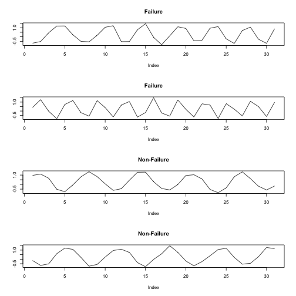

```r
timeWindow = 30 # time window to examine
failures = which(frequencyChangeDS$failure==1)
par(mfrow=c(4,1))
plot(frequencyChangeDS[(failures[20]-timeWindow):failures[20],]$signal1,type="l",ylab=NA,main = "Failure")
plot(frequencyChangeDS[(failures[5000]-timeWindow):failures[5000],]$signal1,type="l",ylab=NA,main = "Failure")
plot(frequencyChangeDS[(failures[1]-timeWindow-500):(failures[1]-500),]$signal1,type="l",ylab=NA,main = "Non-Failure")
plot(frequencyChangeDS[(failures[1]-timeWindow-1000):(failures[1]-1000),]$signal1,type="l",ylab=NA,main = "Non-Failure")
```

The differences are clearest in the frequency domain:

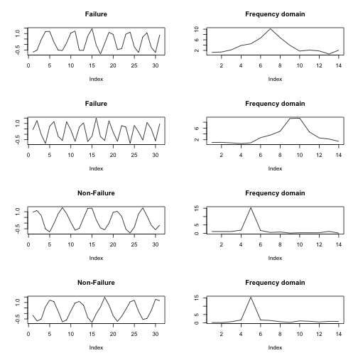

```r
par(mfrow=c(4,2))
plot(frequencyChangeDS[(failures[20]-timeWindow):failures[20],]$signal1,type="l",ylab=NA,main = "Failure")
plot(abs(fft(frequencyChangeDS[(failures[20]-timeWindow):failures[20],]$signal1))[2:(timeWindow/2)],ylab=NA,type="l",main = "Frequency domain")
plot(frequencyChangeDS[(failures[5000]-timeWindow):failures[5000],]$signal1,type="l",ylab=NA,main = "Failure")
plot(abs(fft(frequencyChangeDS[(failures[5000]-timeWindow):failures[5000],]$signal1))[2:(timeWindow/2)],ylab=NA,type="l",main = "Frequency domain")
plot(frequencyChangeDS[(failures[1]-timeWindow-500):(failures[1]-500),]$signal1,type="l",ylab=NA,main = "Non-Failure")
plot(abs(fft(frequencyChangeDS[(failures[1]-timeWindow-500):(failures[1]-500),]$signal1))[2:(timeWindow/2)],ylab=NA,type="l",main = "Frequency domain")
plot(frequencyChangeDS[(failures[1]-timeWindow-1000):(failures[1]-1000),]$signal1,type="l",ylab=NA,main = "Non-Failure")
plot(abs(fft(frequencyChangeDS[(failures[1]-timeWindow-1000):(failures[1]-1000),]$signal1))[2:(timeWindow/2)],ylab=NA,type="l",main = "Frequency domain")
```

The failures are characteried by wider band signals and higher frequency ranges

In order to model this particular problem the features need to be represented as a windowed time series:

```r
frequencyChangeDSwindowed = addTimeWindow(data = frequencyChangeDS, dateCol = "date", window = timeWindow, unit="Days",dateFormat = "%a %b %d %H:%M:%S %z %Y",relativeTime=FALSE, offset = 0)
print(xtable(head(frequencyChangeDSwindowed,n=5)), type='html', comment=F)
```

|  | date | signal1 | failure | last_30_Days |
| --- | --- | --- | --- | --- |
| 1 | Sat Jan 02 00:00:00 -0500 1999 | 1.21 | 0 | TW:NA,12/03/1998 00:00:00 AM EST,01/02/1999 00:00:00 AM EST,FALSE,FALSE,Days,2147483647 |
| 2 | Sun Jan 03 00:00:00 -0500 1999 | 1.03 | 0 | TW:NA,12/04/1998 00:00:00 AM EST,01/03/1999 00:00:00 AM EST,FALSE,FALSE,Days,2147483647 |
| 3 | Mon Jan 04 00:00:00 -0500 1999 | 0.46 | 0 | TW:NA,12/05/1998 00:00:00 AM EST,01/04/1999 00:00:00 AM EST,FALSE,FALSE,Days,2147483647 |
| 4 | Tue Jan 05 00:00:00 -0500 1999 | -0.48 | 0 | TW:NA,12/06/1998 00:00:00 AM EST,01/05/1999 00:00:00 AM EST,FALSE,FALSE,Days,2147483647 |
| 5 | Wed Jan 06 00:00:00 -0500 1999 | -0.66 | 0 | TW:NA,12/07/1998 00:00:00 AM EST,01/06/1999 00:00:00 AM EST,FALSE,FALSE,Days,2147483647 |

Now that we have the sliding window column prepared we will split the data temporally to a testing and training set. We will retain only the target and time window information (including the date) in the training and testing data and access the actual signal (and any other columns) in a context dataset (date will serve as a key). The train and test data only hold logical information regarding the time windows which is constructed during matching with the context data set which holds the actual signal. This allows us to construct the windows in memory and we do not need to hold all the overlapping time windows in the training and testing data.

```r
# keep only date, target and sliding window parameters
trainData = frequencyChangeDSwindowed[,c("date","failure",paste0("last_",timeWindow, "_Days"))]
# keep only the key (date in our case) and all other signals/columns
contextData = frequencyChangeDSwindowed[,c("date","signal1")]
```

#### Pipeline

```r
frequencyModel = learn(
    projectName = "frequency_change_example",
    trainData = trainData,
    target = "failure",
    # we split the data into train and test by the date column. Features will not be looked at on the date column
    problemDefinition = problemDefinitionControl(trainTestSplitRatio = 0.6, temporalSplitColumn="date"),
    contextDatasets = list(contextObject(data = contextData, name = "signals",
        contextTypes = contextTypesList(timeSeries = TRUE))),
    featureGeneration = featureGenerationControl(maxFeaturesCount = list(25))
)
```

#### Top features

The model finds the exact anomolies causing the failure: frequency content outside the range of the carrier signal as well as gradient and slope changes.

```r
print(xtable(frequencyModel$features()[1:4,c("idx","feature")]), type='html', comment=F)
```

|  | idx | feature |
| --- | --- | --- |
| 1 | 0 | -minSlope(window(last_30_Days, signals_signal1)) not in range (1.0732027434606483E-8, 1.644621759085648E-8) |
| 2 | 1 | window(last_30_Days, signals_signal1).lastTime in range (2017.04.09 20:00, 2026.05.18 08:00) |
| 3 | 2 | minSlope(smoothMovingAverage10(window(last_30_Days, signals_signal1))) not in range (-2.6854244626736107E-9, -2.018343268402778E-9) |
| 4 | 3 | stddev(smoothMovingAverage10(window(last_30_Days, signals_signal1))) in range (0.012995010029908771, 0.12750652011173863) |

#### Evaluation

```r
frequencyModelEvaluation = frequencyModel$evaluate()
```

```r
## === Detailed Accuracy By Class ===
##
## Class           TP Rate   FP Rate   Precision   Recall   F-Measure   ROC Area   Gini
##
## 0               0.999     0.052     0.836       0.999    0.911       0.992      0.984
## 1               0.948     0.001     1.0         0.948    0.973       0.992      0.984
## Weighted Avg.   0.959     0.011     0.966       0.959    0.96        0.992      0.984
##
```

# F. Additional World knowledge resources

## External data

[figure not shown]

#### Overview

Goal: what is common to these countries?

#### Training data

Here are all the columns available:

```r
data = getData("countries")
print(xtable(data[1:5,]), type='html', comment=F)
```

|  | country | label |
| --- | --- | --- |
| 1 | british virgin islands | red |
| 2 | indonesia | blue |
| 3 | kazakhstan | blue |
| 4 | angola | blue |
| 5 | national transitional council | blue |

#### Pipeline

```r
countriesModel = learn(
    projectName = "countries",
    trainData = data,
    target = "label",
    knowledge = knowledgeControl(linkedDataCore = TRUE),
    featureGeneration = featureGenerationControl(maxFeaturesCount = 20,maxDepth = 3)
)
```

#### Top features

```r
print(xtable(countriesModel$features()[1:10, c("feature","RIG")]), type='html', comment=F)
```

|  | feature | RIG |
| --- | --- | --- |
| 1 | country leaderName hasGender contains female | 0.93 |
| 2 | country.expandForward.zipWithIndex.valueOf("NodePath(category,dc:constitutional_monarchies)") orIfMissing 31 < 19 | 0.06 |
| 3 | country.expandForward.valueOf("geo:lat, disambiguates") orIfMissing -59.45000076293945 in range (-34.016666412353516, 24.016666412353516) | 0.06 |
| 4 | country category broader contains constitutional monarchies | 0.04 |
| 5 | country.expand.valueOf("numberOfEmployees, !o:location") orIfMissing 0 in range (180, 375) | 0.05 |
| 6 | deviation(country.latLongs) in range (15.710010489367578, 29.065404204962505) | 0.04 |
| 7 | country.expand.valueOf("areaTotal, !o:location") orIfMissing 2.24E+10 < 3250000 | 0.03 |
| 8 | country.expand.zipWithIndex contains (NodePath(type,ol:book), 671) | 0.04 |
| 9 | country.expand.valueOf("birthYear, !o:birthPlace") orIfMissing 1997 < 1855 | 0.05 |
| 10 | country headquarter language contains french language | 0.03 |

#### Evaluation

```r
evaluation = countriesModel$evaluate()
```

```r
## === Detailed Accuracy By Class ===
##
## Class           TP Rate   FP Rate   Precision   Recall   F-Measure   ROC Area   Gini
##
## blue            1         0         1           1        1           1          1
## red             1         0         1           1        1           1          1
## Weighted Avg.   1         0         1           1        1           1          1
##
```

## External datasets and APIs

### Combining airports locations and weather API

Goal: Flights weather delay In this example we use data from Kaggle that contains information of flight delays caused due to weather conditions.

This example will show how airport codes (in fields `origin`, `dest`) are automatically identified as airport entities and are enriched with the corresponding latitude and longitude information of the airport. Moreover, when elements of type date and location are encountered during the feature search, external data including NOAA weather are examined for their distinctive power. The first run may take more time as weather data will be downloaded and cached.

```r
library(xtable)
flights = getData("flights_delay")
names(flights)
```

[1] "year" "month" "dayofMonth"  
[4] "dayOfWeek" "depTime" "cRSDepTime"  
[7] "arrTime" "cRSArrTime" "uniqueCarrier"  
[10] "flightNum" "tailNum" "actualElapsedTime" [13] "cRSElapsedTime" "airTime" "origin"  
[16] "dest" "distance" "taxiIn"  
[19] "taxiOut" "cancelled" "cancellationCode" [22] "diverted" "weatherDelay" "lateAircraftDelay" [25] "date"

```r
print(xtable(tail(airports,n=5)), type='html', comment=F) # show the airport database
```

|  | Name | City | Country | IATA | ICAO | Latitude | Longitude | Altitude | Timezone | DST | TZ.timezone |
| --- | --- | --- | --- | --- | --- | --- | --- | --- | --- | --- | --- |
| 5876 | Mansons Landing Water Aerodrome | Mansons Landing | Canada | YMU |  | 50.07 | -124.98 | 0 | -8.00 | A | America/Vancouver |
| 5877 | Port McNeill Airport | Port McNeill | Canada | YMP |  | 50.58 | -127.03 | 225 | -8.00 | A | America/Vancouver |
| 5878 | Sullivan Bay Water Aerodrome | Sullivan Bay | Canada | YTG |  | 50.88 | -126.83 | 0 | -8.00 | A | America/Vancouver |
| 5879 | Deer Harbor Seaplane | Deer Harbor | United States | DHB |  | 48.62 | -123.01 | 0 | -8.00 | A | America/Los_Angeles |
| 5880 | San Diego Old Town Transit Center | San Diego | United States | OLT |  | 32.76 | -117.20 | 0 | -8.00 | A | America/Los_Angeles |

The airport data will be loaded automatically as a customGraph but you could explicitly send it using contextDatasets (as in Example 5). Regardless of modality (customGraph or contextDatasets) the functionality is identical and the engine will automatically detect relevant columns in the airport data (or any other dataset)

```r
flightSampled = sampleDataAbsolute(flights,5000)
flightsModel = learn(
        projectName = "flights_delay_example",
    trainData = flightSampled,
    target = "weatherDelay",
    featureGeneration = featureGenerationControl(
            maxFeaturesCount = list(30),
            functionsBlackList = list("trigonometry")
        ),
        knowledge = knowledgeControl(linkedDataCore = TRUE),
    modelBuilding = modelBuildingControl(algorithmsWhiteList = list("RXGBoostRegressor")),
    autoSave = FALSE
)
```

```r
print(flightsModel$evaluate()$evaluation$rootMeanSquaredError)
```

```r
##
## [1] 64.62227
```

```r
print(xtable(flightsModel$features()[1:20,c("idx","feature")]), type='html', comment=F)
```

|  | idx | feature |
| --- | --- | --- |
| 1 | 0 | log1p(arrTime) in range (3.569433499972762, 6.410996574838032) |
| 2 | 1 | taxiOut >= 50 |
| 3 | 2 | Weather.contentForLatLongDate(lookupGeo(dest, table_airports_by_iata), date).valueOf("SLP2") orIfMissing 0 in range (12.5, 22.5) |
| 4 | 3 | Weather.contentForLatLongDate(lookupGeo(origin, table_airports_by_iata), date).valueOf("VISIB") orIfMissing 0 >= 9.350000000000001 |
| 5 | 4 | depTime < 549 |
| 6 | 5 | depTime not in range (548.5, 2244.5) |
| 7 | 6 | uniqueCarrier.min == A |
| 8 | 7 | Weather.contentForLatLongDate(lookupGeo(dest, table_airports_by_iata), date).valueOf("SLP") orIfMissing 0 >= 1016.75 |
| 9 | 8 | Weather.contentForLatLongDate(lookupGeo(origin, table_airports_by_iata), date).valueOf(" STP") orIfMissing 0 < 978.75 |
| 10 | 9 | date == Sun Jul 13 03:00:00 IDT 2008 |
| 11 | 10 | Weather.contentForLatLongDate(lookupGeo(dest, table_airports_by_iata), date) does not contain (RAIN_EXISTS, 0) |
| 12 | 11 | uniqueCarrier == OO |
| 13 | 12 | Weather.contentForLatLongDate(lookupGeo(origin, table_airports_by_iata), date) contains (FOG_EXISTS, 1) |
| 14 | 13 | lookupNumeric(origin, table_airports_by_iata).valueOf(latitude) orIfMissing 0 not in range (33.444, 41.91179150000001) |
| 15 | 14 | Weather.contentForLatLongDate(lookupGeo(dest, table_airports_by_iata), date) contains (DEWP, 62.6) |
| 16 | 15 | sigmoid(arrTime) in range (0.9999999994813985, 0.9999999999999999) |
| 17 | 16 | Weather.contentForLatLongDate(lookupGeo(dest, table_airports_by_iata), date).valueOf("VISIB") orIfMissing 0 >= 9.55 |
| 18 | 17 | date == Sat Mar 22 02:00:00 IST 2008 |
| 19 | 18 | Weather.contentForLatLongDate(lookupGeo(dest, table_airports_by_iata), date) does not contain (THUNDER_EXISTS, 0) |
| 20 | 19 | date == Fri Feb 22 02:00:00 IST 2008 |

```r
writeLines(readLines(paste0(flightsModel$artifact_loc,"/reports/features/features_trace.txt"),n=9))
```

```r
## Human friendly: log1p(arrTime) in range (3.569433499972762, 6.410996574838032)
## Canonical: (scala.math.abs(scala.math.log1p(arrTime) - 4.990215037405397)) < 1.4207815374326351
## +-----------------------------------------+----------------------+--------------------+--------+----------------------------------------+---------------------------------------------------------------+
## | sub-expression                          | positive sample      | negative sample    | type   | root function                          | reference / explanation                                       |
## +-----------------------------------------+----------------------+--------------------+--------+----------------------------------------+---------------------------------------------------------------+
## | abs(log1p(arrTime) - 4.990215037405397) | 0.22804110260764077  | 1.732118499383915  | Double | scala.math.abs(x: Double): Double      | http://www.scala-lang.org/api/current/index.html#scala.math   |
## |  log1p(arrTime) - 4.990215037405397     | -0.22804110260764077 | -1.732118499383915 | Double | scala.Double.$minus(x: Double): Double | http://www.scala-lang.org/api/current/index.html#scala.Double |
## |   log1p(arrTime)                        | 4.762173934797756    | 3.258096538021482  | Double | scala.math.log1p(x: Double): Double    | http://www.scala-lang.org/api/current/index.html#scala.math   |
## |    arrTime                              | 116                  | 25                 | Int    | arrTime                                | Input parameter 'arrTime'                                     |
```

# G. Advanced feature controls

## Deep feature search with pairs

Goal: identify dependencies across variables and time series (Google Stock)

```r
googleStock = getData("googleStock")
print(xtable(head(googleStock,n=5)), type='html', comment=F)
```

|  | date | ticker | open | high | low | close | volume | close_sliding | criticalDay | happy |
| --- | --- | --- | --- | --- | --- | --- | --- | --- | --- | --- |
| 1 | Mon Oct 05 00:00:00 EDT 2009 | GOOG | 487.67 | 492.43 | 483.34 | 488.52 | 21264 | [465.24,468.73,471.37,468.0,466.06,464.75,461.67,455.761,453.01,457.52,461.3,463.97,470.94,472.14,475.12,477.54,488.29,491.72,491.46,497.0,499.06,498.46,496.77,492.48,498.53,498.53,495.85,487.2,484.58… | 16 | true |
| 2 | Tue Oct 06 00:00:00 EDT 2009 | GOOG | 492.37 | 499.37 | 491.70 | 498.74 | 27329 | [468.73,471.37,468.0,466.06,464.75,461.67,455.761,453.01,457.52,461.3,463.97,470.94,472.14,475.12,477.54,488.29,491.72,491.46,497.0,499.06,498.46,496.77,492.48,498.53,498.53,495.85,487.2,484.58,488.52… | 0 | true |
| 3 | Wed Oct 07 00:00:00 EDT 2009 | GOOG | 498.97 | 518.99 | 497.81 | 517.54 | 48776 | [471.37,468.0,466.06,464.75,461.67,455.761,453.01,457.52,461.3,463.97,470.94,472.14,475.12,477.54,488.29,491.72,491.46,497.0,499.06,498.46,496.77,492.48,498.53,498.53,495.85,487.2,484.58,488.52,498.74… | 14 | true |
| 4 | Thu Oct 08 00:00:00 EDT 2009 | GOOG | 519.58 | 523.25 | 513.34 | 514.18 | 43065 | [468.0,466.06,464.75,461.67,455.761,453.01,457.52,461.3,463.97,470.94,472.14,475.12,477.54,488.29,491.72,491.46,497.0,499.06,498.46,496.77,492.48,498.53,498.53,495.85,487.2,484.58,488.52,498.74,517.54… | 16 | true |
| 5 | Fri Oct 09 00:00:00 EDT 2009 | GOOG | 516.43 | 521.51 | 514.50 | 516.25 | 27398 | [466.06,464.75,461.67,455.761,453.01,457.52,461.3,463.97,470.94,472.14,475.12,477.54,488.29,491.72,491.46,497.0,499.06,498.46,496.77,492.48,498.53,498.53,495.85,487.2,484.58,488.52,498.74,517.54,514.1… | 12 | true |

The target variable reflects if the google closing price today was more than the closing price at a critical time point in the past. Let's split the data sequntially and first try a regular model at depth = 2

```r
googleTrainTest = trainTestSplit(googleStock)
```

```r
googleModel = learn(
    projectName = "googleStock",
    trainData = googleTrainTest[[1]],
    testData = googleTrainTest[[2]],
    target = "happy",
    featureGeneration = featureGenerationControl(
            maxFeaturesCount = 50
    )
)
googleModelEval = googleModel$evaluate()
```

```r
print(xtable(googleModel$features()[1:5,c("idx","feature")]), type='html', comment=F)
```

|  | idx | feature |
| --- | --- | --- |
| 1 | 0 | globalDelta(close_sliding) < -3.051999999999964 |
| 2 | 1 | criticalDay in range (9, 12.5) |
| 3 | 2 | tan(open) in range (1.7427707890041493, 10.96881210720018) |
| 4 | 3 | close_sliding.zipWithIndex.valueOf("563.54") orIfMissing 0 >= 15 |
| 5 | 4 | tan(close) in range (1.136782707100604, 5.621293751828938) |

```r
e=googleModel$evaluate()$summary
```

```r
## === Detailed Accuracy By Class ===
##
## Class           TP Rate   FP Rate   Precision   Recall   F-Measure   ROC Area   Gini
##
## true            1         0         1           1        1           1          1
## false           1         0         1           1        1           1          1
## Weighted Avg.   1         0         1           1        1           1          1
##
```

Now let's enable a deep feature search using an advanced feature search with pairs.

```r
googleModelAdvanced = learn(projectName = "googleStockAdvanced",
    trainData = googleTrainTest[[1]],
    testData = googleTrainTest[[2]],
    target = "happy",
        featureGeneration = featureGenerationControl(
                    featureSearchMode = "ADVANCED_WITH_PAIRS",
                    maxFeaturesCount = 50,
                    maxFeatureDuration=5
        )
)
```

```r
print(xtable(googleModelAdvanced$features()[1:1,c("idx","feature")]), type='html', comment=F)
```

|  | idx | feature |
| --- | --- | --- |
| 1 | 0 | average(derivativeY(close_sliding).drop(criticalDay)) < -0.04053124999999937 |

```r
e=googleModelAdvanced$evaluate()$summary
```

```r
## === Detailed Accuracy By Class ===
##
## Class           TP Rate   FP Rate   Precision   Recall   F-Measure   ROC Area   Gini
##
## true            1         0         1           1        1           1          1
## false           1         0         1           1        1           1          1
## Weighted Avg.   1         0         1           1        1           1          1
##
```

## Deep feature search with many interactions

Goal: Complex Sum

Target = (f_1 * Math.log(1.0 + f_1) + f_2 + f_3 + f_4) / 5  
Noise = values(f_5 -> f_7) noise random int in 1 to 100

```r
complexSum = getData("complexSum")
print(xtable(head(complexSum,n=5)), type='html', comment=F)
```

|  | f_0 | f_1 | f_2 | f_3 | f_4 | f_5 | f_6 | f_7 | tgt |
| --- | --- | --- | --- | --- | --- | --- | --- | --- | --- |
| 1 | 31 | 22 | 39 | 57 | 68 | 55 | 6 | 83 | 52.24 |
| 2 | 6 | 1 | 94 | 66 | 66 | 12 | 3 | 53 | 46.03 |
| 3 | 8 | 35 | 33 | 16 | 4 | 72 | 55 | 82 | 16.33 |
| 4 | 21 | 3 | 8 | 43 | 26 | 87 | 85 | 0 | 21.22 |
| 5 | 56 | 97 | 11 | 45 | 35 | 98 | 67 | 4 | 69.55 |

```r
complexSumModel = learn(
    projectName = "complexSum",
    trainData = complexSum,
    target = "tgt",
    featureGeneration = featureGenerationControl(
            maxFeaturesCount = 25
     )
)
```

```r
complexSumModel$evaluate()$evaluation$rootMeanSquaredError
```

```r
##
## Correlation coefficient             0.971378
## R2                                  0.943574
## Mean absolute error                 5.53591
## Root mean squared error             7.392209
## Relative absolute error             25.68159762 %
## Root relative squared error         28.01738009 %
## Root relative prior squared error   26.38436863
## Actuals mean                        69.85551708
## Estimations mean                    69.52007149
## Actuals std                         26.03583105
## Estimations std                     21.25537259
## Total Number of Instances           203
##
```

```r
## [1] 7.392209
```

```r
complexSumAdvancedModel = learn(
    projectName = "complexSumAdvanced",
    trainData = complexSum,
    target = "tgt",
    featureGeneration = featureGenerationControl(
                featureSearchMode = "DIG_DEEP",
                maxFeaturesCount = 25
    )
)
```

```r
print(xtable(complexSumAdvancedModel$features()[1:5,c("idx","feature")]), type='html', comment=F)
```

|  | idx | feature |
| --- | --- | --- |
| 1 | 0 | pow(leftSlantedWeightedAverage(f_0, f_4), sigmoid(cbrt(f_1))) >= 44.59896762630707 |
| 2 | 1 | pow(sin(log10(f_0)), cbrt(f_1)) < 0.849308486410637 |
| 3 | 2 | rightSlantedWeightedAverage(f_3, f_0) < 48.5 |
| 4 | 3 | rightSlantedWeightedAverage(leftSlantedGeometricMean(squared(f_0), sqrt(f_1)), f_2) >= 167.11767207517522 |
| 5 | 4 | leftSlantedGeometricMean(sinh(f_0), log1p(f_1)).toInt < 64099219 |

```r
complexSumAdvancedModel$evaluate()$evaluation$rootMeanSquaredError
```

```r
##
## Correlation coefficient             0.986627
## R2                                  0.973432
## Mean absolute error                 3.105214
## Root mean squared error             4.431243
## Relative absolute error             14.40537614 %
## Root relative squared error         16.79495546 %
## Root relative prior squared error   26.38436863
## Actuals mean                        69.85551708
## Estimations mean                    69.94605408
## Actuals std                         26.03583105
## Estimations std                     24.41554189
## Total Number of Instances           203
##
```

```r
## [1] 4.431243
```

## Cross row search

Goal: Identify changes in density of specific rows  
In this example, we will generate 500 random points in Euclidean space, and we will set as target for each point, the inverse of the minimal distance from all other points.

```r
n = 500
data = data.table(lat=runif(n), long = runif(n))
data[,target:=sapply(1:n, function(i) 1/min({a = (data$lat[i]-data$lat)^2+(data$long[i]-data$long)^2; a[i] = Inf;a}))]
densityModel = learn(projectName = "density_example",
    trainData = data,
    target = "target",
        featureGeneration = featureGenerationControl(
            # indicates that points from all rows should be considered together during feature search
        crossRowFeatureSearch = TRUE,
      maxFeaturesCount = 5,
        maxDepth = 3,                               # allowing a higher search space depth
        functionsBlackList = list("trigonometry")  # blacklist trigonometric functions
    ),
    modelBuilding = modelBuildingControl(algorithmsWhiteList = list("RRandomForestRegressor")),
    autoSave = FALSE
)
```

Note that in this example:  
1. While we provided the columns `lat` and `long` as two separate columns, a new feature named `latLong` was created that can operate in the 2D space. 2. The resulting best feature was able to capture our target by being able to generate features using the entire column information.

```r
library(xtable)
topFeatures = densityModel$features()[1:3,c("idx","feature")]
print(xtable(topFeatures), type='html', comment=F)
```

|  | idx | feature |
| --- | --- | --- |
| 1 | 0 | inverse(distance of latLong from closest of latLong_column) >= 0.6940667049710194 |
| 2 | 1 | ceil(distance of latLong from closest of latLong_column) == 2.0 |
| 3 | 2 | ceil(distance of latLong from closest of latLong_column) == 1.0 |

```r
writeLines(readLines(paste0(densityModel$artifact_loc,"/reports/features/features_trace.txt"),n=9))
```

```r
## Human friendly: inverse(distance of latLong from closest of latLong_column) >= 0.6940667049710194
## Canonical: (core.Solving.SpecialFunctions.inverse(core.common.zeroComplexity.ZeroComplexityFunctions.distanceFromClosest(core.LoadCached[scala.collection.immutable.Vector[core.datastructures.LatLong]]("/Users/zinman/localdata/artifacts/density_example/6/resources/latLong_column"), latLong))) >= 0.6940667049710194
## +--------------------------------------------------------------------------------------------------------------------------------------------------------------------------------------------------------+--------------------------------------------+----------------------------------------------+-----------------------------+-------------------------------------------------------------------------------------------------------------------------------------------------------------+---------------------------+
## | sub-expression                                                                                                                                                                                         | positive sample                            | negative sample                              | type                        | root function                                                                                                                                               | reference / explanation   |
## +--------------------------------------------------------------------------------------------------------------------------------------------------------------------------------------------------------+--------------------------------------------+----------------------------------------------+-----------------------------+-------------------------------------------------------------------------------------------------------------------------------------------------------------+---------------------------+
## | inverse(distanceFromClosest(core.LoadCached[scala.collection.immutable.Vector[core.datastructures.LatLong]]("/Users/zinman/localdata/artifacts/density_example/6/resources/latLong_column"), latLong)) | 0.7282626904504894                         | 0.3479900011460833                           | Double                      | core.Solving.SpecialFunctions.inverse(num: Double): Double                                                                                                  | 1 / num                   |
## |  distanceFromClosest(core.LoadCached[scala.collection.immutable.Vector[core.datastructures.LatLong]]("/Users/zinman/localdata/artifacts/density_example/6/resources/latLong_column"), latLong)         | 1.3731308950914662                         | 2.8736457849552073                           | Double                      | core.common.zeroComplexity.ZeroComplexityFunctions.distanceFromClosest(points: Seq[core.datastructures.LatLong],point: core.datastructures.LatLong): Double |                           |
## |   latLong                                                                                                                                                                                              | LatLong(0.39135928102769,0.52709619468078) | LatLong(0.856131664710119,0.828075018012896) | core.datastructures.LatLong | latLong                                                                                                                                                     | Input parameter 'latLong' |
## +--------------------------------------------------------------------------------------------------------------------------------------------------------------------------------------------------------+--------------------------------------------+----------------------------------------------+-----------------------------+-------------------------------------------------------------------------------------------------------------------------------------------------------------+---------------------------+
```

## Add custom functions

Goal: Identify numbers that are multiples of 7 You can create your own functions, which will be used as building blocks during the feature search. All you need to do, is to specify the url/s of the source files containing the custom functions code (currently only Scala is supported). The file can be local (on the server) or on the web.

```r
data = data.frame(number = 1:500, target = 1:500 %% 7 == 0)
```

```r
modModel = learn(projectName = "custom_function_example",
    trainData = data,
    target = "target",
    featureGeneration = featureGenerationControl(maxFeaturesCount = 5),
    # using a function from the web in the following url
    knowledge = knowledgeControl(customFunctions = list("https://raw.githubusercontent.com/mesagie/etcetra/master/SampleFunctions.scala")),
    modelBuilding = modelBuildingControl(algorithmsWhiteList = list("RRandomForestClassifier")),
    autoSave = FALSE
)
```

```r
modModel$features()[1:1,c("idx","feature")]
```

idx feature 1 0 number in range (350.5, 398)

# I. More info

For more information please check:

- `tutorial()` : [Getting started tutorial](https://s3.amazonaws.com/public-sparkbeyond/tutorial.html)
- `examples()` : [These examples](https://s3.amazonaws.com/public-sparkbeyond/examples-master.html)
- `SBhelp()` : [html help of this package](https://s3.amazonaws.com/public-sparkbeyond/SBadapterDocs/index.html)
- `faq()` : [Frequently Asked Quetions](https://docs.google.com/document/d/1MfUduRR2jZiLaZPfc8Q68ijvWctjNKgg7smeqEoH9yk/pub)
- `reportsList()`: [explantion of all the reports produced by the SparkBeyond engine](https://docs.google.com/document/d/16ogU45DHrW0x_BVLS5TiyPMblORUGSxaScR8i_lIDI0)
- `resources()` : [various SparkBeyond resources](https://docs.google.com/document/d/1wF7EkdyEB8409blpkianOyQxvi-OWasVEGegdLk-MOI/pub)

Styled with knitrBootstrap